# Adequate antibiotic knowledge in Serbian primary-care attenders

Dataset 1: Antibiotic knowledge and self-medication in Serbia

RSR feasibility analysis

2026-08-03

# Introduction

Public campaigns against antibiotic misuse are usually evaluated against a pass mark: what share of the population knows enough. These data come from a cross-sectional questionnaire survey of 500 adults who consulted general practitioners at four health centres in Serbia, reported by Horvat and colleagues (*PLOS ONE* 2017;12(7):e0180799). Each respondent answered a 12-item antibiotic quiz, and the source paper classified a score of 9 or more as adequate knowledge; 308 of 500 respondents (62%) clear that bar. Knowing which groups fall below it is what tells a campaign where to aim.

**Aim.** Among Serbian adults attending primary care, we examined which of age group, sex, education, employment status, frequency of GP contact and having a health professional in the family are independently associated with achieving adequate antibiotic knowledge, mutually adjusting for the others.

This is a *Purpose 3* analysis: several predictors are of interest and the question is which remain associated with the outcome after mutual adjustment.

# Methods

**Data source.** Cross-sectional, interviewer-administered questionnaire survey of adults consulting general practitioners at four Serbian health centres; 500 respondents completed the entire questionnaire and all 500 are analysed here. All measurements were taken on a single occasion.

**Variables.** The outcome is `adequate_knowledge`, a binary indicator; the modelled event is **adequate knowledge = yes**, defined by the source paper as a score of 9 or more out of 12 (308 events, 192 non-events, so the rarer class has 192). Predictors are `age_group` (six bands; reference: over 65, the largest band at n = 123), `sex` (reference: female, n = 304), `education_level` (primary / secondary / tertiary; reference: secondary, the largest group at n = 259), `employment_status` (reference: employed, n = 251), `gp_visits_past_year` (four bands of visits in the previous 12 months; reference: none, the group with no primary-care contact, n = 135) and `health_professional_in_family` (reference: no, n = 374). All six are categorical, so every estimate is an odds ratio against the stated reference level; the file contains no continuous predictors.

**`knowledge_score` is not a predictor here, and cannot be.** The outcome is exactly the indicator `knowledge_score >= 9` and nothing else. In this file the respondents flagged 0 score 2 to 8 and those flagged 1 score 9 to 12, with no overlap; re-deriving the flag from the score reproduces the deposited column exactly (`identical()` returns TRUE, with 0 disagreements out of 500). Entering the score in this model is textbook complete separation: the fitted coefficient diverges, the standard error explodes, and `glm()` returns a meaningless answer with a convergence warning. The two columns are one outcome measured two ways — continuous and dichotomised — so exactly one of them can be the response in any given analysis and the other must be left out entirely. The same file’s continuous version of this analysis is in `knowledge_score.Rmd`; the two documents answer the same question and should be read as alternatives, not as complements.

Two of the eight background variables were also left out deliberately. `marital_status` is largely a restatement of age here (Cramér’s V = 0.55 with `age_group`), and `household_size` has no plausible link to what a person knows about antibiotics and none in the data (univariable p = 0.091). `self_medication` is a behaviour and a plausible *consequence* of knowledge rather than a cause of it, so it is not used as a predictor. `id` is a row number and is never modelled.

**Statistical analysis.** Logistic regression (`glm(family = binomial)`), justified because the outcome is binary. We fitted a univariable model for each predictor first, then a single multivariable model containing all of them. Predictors were chosen in advance on subject-matter grounds, not by significance. Estimates are odds ratios with 95% confidence intervals; significance threshold 0.05. Assumptions were checked with `performance::check_model()`, with attention to binned residuals, collinearity and influential observations rather than to normality or constant variance, which do not apply to a logistic model. Analysis used R version 4.6.0 (2026-04-24) with tidyverse, gtsummary and performance.

**Missing data.** There is none. Every one of the 12 columns is 100% complete, so the model uses all 500 of 500 rows and 0 were dropped. There is no missing-data story to tell for this file, and it would be wrong to manufacture one — though the survey retained only respondents who completed the whole questionnaire, so partial responders were excluded upstream and nothing is known about them.

# Results

## Sample characteristics

**Table 1. Sample characteristics, by adequate-knowledge status.**

| **Characteristic** | **N** | **Overall** N = 500<sup>1</sup> | **Score 2-8** N = 192<sup>1</sup> | **Score 9-12 (adequate)** N = 308<sup>1</sup> |
| --- | --- | --- | --- | --- |
| age_group | 500 |  |  |  |
| Over 65 |  | 123 (25%) | 69 (36%) | 54 (18%) |
| 18-24 |  | 25 (5.0%) | 7 (3.6%) | 18 (5.8%) |
| 25-34 |  | 78 (16%) | 25 (13%) | 53 (17%) |
| 35-44 |  | 70 (14%) | 21 (11%) | 49 (16%) |
| 45-54 |  | 104 (21%) | 36 (19%) | 68 (22%) |
| 55-64 |  | 100 (20%) | 34 (18%) | 66 (21%) |
| sex | 500 |  |  |  |
| Female |  | 304 (61%) | 109 (57%) | 195 (63%) |
| Male |  | 196 (39%) | 83 (43%) | 113 (37%) |
| education_level | 500 |  |  |  |
| Secondary |  | 259 (52%) | 125 (65%) | 134 (44%) |
| Primary |  | 38 (7.6%) | 28 (15%) | 10 (3.2%) |
| Tertiary |  | 203 (41%) | 39 (20%) | 164 (53%) |
| employment_status | 500 |  |  |  |
| Employed |  | 251 (50%) | 72 (38%) | 179 (58%) |
| Unemployed |  | 114 (23%) | 48 (25%) | 66 (21%) |
| Pensioner |  | 135 (27%) | 72 (38%) | 63 (20%) |
| gp_visits_past_year | 500 |  |  |  |
| None |  | 135 (27%) | 42 (22%) | 93 (30%) |
| 1-4 |  | 223 (45%) | 85 (44%) | 138 (45%) |
| 5-10 |  | 72 (14%) | 37 (19%) | 35 (11%) |
| More than 10 |  | 70 (14%) | 28 (15%) | 42 (14%) |
| health_professional_in_family | 500 | 126 (25%) | 34 (18%) | 92 (30%) |

<sup>1</sup> n (%)

## Exploratory figure

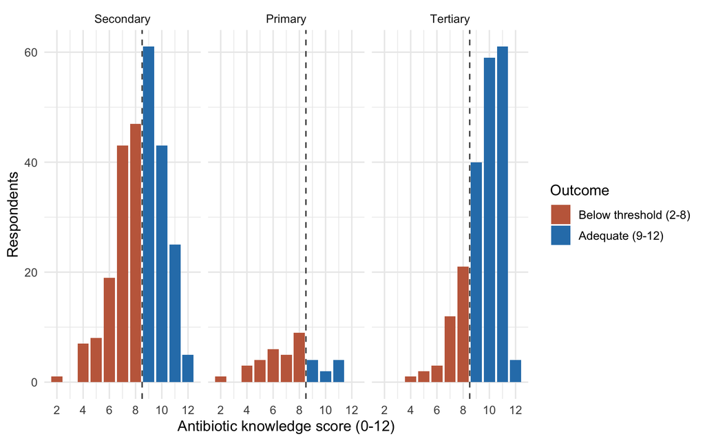

Figure 1. Distribution of the underlying 12-item knowledge score within each education level, shaded by whether the respondent clears the adequate-knowledge threshold. The dashed line is the cut at 9; the outcome modelled here is nothing more than which side of that line a respondent falls.

The whole score distribution shifts right as education rises — the tertiary panel is dominated by scores of 10 and above while the primary panel sits mostly below the line — and the figure makes plain what the outcome is: a single cut through a continuous score, which throws away the difference between a score of 2 and a score of 8, and between 9 and 12.

## Univariable models

| **Characteristic** | **N** | **OR** | **95% CI** | **p-value** |
| --- | --- | --- | --- | --- |
| age_group | 500 |  |  |  |
| Over 65 |  | — | — |  |
| 18-24 |  | 3.29 | 1.33, 8.98 | 0.013 |
| 25-34 |  | 2.71 | 1.51, 4.96 | 0.001 |
| 35-44 |  | 2.98 | 1.62, 5.64 | <0.001 |
| 45-54 |  | 2.41 | 1.42, 4.16 | 0.001 |
| 55-64 |  | 2.48 | 1.44, 4.31 | 0.001 |
| sex | 500 |  |  |  |
| Female |  | — | — |  |
| Male |  | 0.76 | 0.53, 1.10 | 0.15 |
| education_level | 500 |  |  |  |
| Secondary |  | — | — |  |
| Primary |  | 0.33 | 0.15, 0.69 | 0.005 |
| Tertiary |  | 3.92 | 2.58, 6.06 | <0.001 |
| employment_status | 500 |  |  |  |
| Employed |  | — | — |  |
| Unemployed |  | 0.55 | 0.35, 0.88 | 0.012 |
| Pensioner |  | 0.35 | 0.23, 0.54 | <0.001 |
| gp_visits_past_year | 500 |  |  |  |
| None |  | — | — |  |
| 1-4 |  | 0.73 | 0.46, 1.15 | 0.2 |
| 5-10 |  | 0.43 | 0.24, 0.77 | 0.005 |
| More than 10 |  | 0.68 | 0.37, 1.24 | 0.2 |
| health_professional_in_family | 500 |  |  |  |
| No |  | — | — |  |
| Yes |  | 1.98 | 1.28, 3.12 | 0.003 |

Abbreviations: CI = Confidence Interval, OR = Odds Ratio

## Why adjustment is needed

The crude odds ratios above cannot be read individually because the background variables in this survey are heavily confounded with one another. `age_group` is the clearest confounder of the education association: 28 of the 38 primary-educated respondents (74%) are over 65, because compulsory schooling expanded in the region within these respondents’ lifetimes, and age is itself associated with failing the knowledge threshold. Unadjusted, part of what looks like an education effect is simply the age composition of the education groups. `employment_status` is the second, and is close to a relabelling of age at the top end: 100 of the 135 pensioners (74%) are over 65, Cramér’s V between age and employment is 0.58, and pensioners are also the least educated group in the sample (20% hold a tertiary degree, against 56% of the employed). The crude pensioner deficit therefore has at least two alternative explanations, age and education, before pensioner status itself is considered. A third route runs through `gp_visits_past_year`, which is strongly age-patterned (62% of the over-65s report five or more visits against 18% of everyone else), so any crude attendance association is partly an age association. Only a model containing all six turns these into within-stratum comparisons.

## Multivariable model

| **Characteristic** | **OR** | **95% CI** | **p-value** |
| --- | --- | --- | --- |
| age_group |  |  |  |
| Over 65 | — | — |  |
| 18-24 | 2.84 | 0.92, 9.49 | 0.077 |
| 25-34 | 1.07 | 0.43, 2.64 | 0.9 |
| 35-44 | 1.28 | 0.52, 3.16 | 0.6 |
| 45-54 | 1.03 | 0.45, 2.31 | >0.9 |
| 55-64 | 1.39 | 0.68, 2.85 | 0.4 |
| sex |  |  |  |
| Female | — | — |  |
| Male | 0.73 | 0.48, 1.11 | 0.14 |
| education_level |  |  |  |
| Secondary | — | — |  |
| Primary | 0.37 | 0.15, 0.81 | 0.017 |
| Tertiary | 3.50 | 2.23, 5.59 | <0.001 |
| employment_status |  |  |  |
| Employed | — | — |  |
| Unemployed | 0.71 | 0.41, 1.23 | 0.2 |
| Pensioner | 0.57 | 0.28, 1.18 | 0.13 |
| gp_visits_past_year |  |  |  |
| None | — | — |  |
| 1-4 | 0.86 | 0.50, 1.44 | 0.6 |
| 5-10 | 0.67 | 0.33, 1.35 | 0.3 |
| More than 10 | 1.56 | 0.74, 3.34 | 0.2 |
| health_professional_in_family |  |  |  |
| No | — | — |  |
| Yes | 1.82 | 1.12, 3.02 | 0.018 |

Abbreviations: CI = Confidence Interval, OR = Odds Ratio

Model fit and events per parameter

| Statistic | Value |
| --- | --- |
| AIC (fitted model) | 607.9 |
| AIC (intercept-only model) | 668.0 |
| Tjur's R-squared | 0.166 |
| Likelihood-ratio test vs null (p) | <0.001 |
| Events (adequate knowledge) | 308 |
| Non-events | 192 |
| Rarer class | 192 |
| Non-intercept parameters | 14 |
| Events per parameter | 13.7 |

With 192 in the rarer outcome class and 14 non-intercept parameters, there are 13.7 events per parameter — above the conventional minimum of ten, but not by a wide margin, so the six-level age factor is close to the limit of what this sample supports. Adjusting for all six predictors, only two associations survive. Education remains dominant: conditional on age, sex, employment, attendance and family health-care exposure, tertiary education carries OR 3.50 (95% CI 2.23 to 5.59, p < 0.001) and primary education OR 0.37 (95% CI 0.15 to 0.81, p = 0.017) relative to secondary. Having a health professional in the family retains OR 1.82 (95% CI 1.12 to 3.02, p = 0.018). Everything else falls away: no age contrast is significant (the largest, 18-24, is OR 2.84 (95% CI 0.92 to 9.49, p = 0.077)), employment status is not (pensioner OR 0.57 (95% CI 0.28 to 1.18, p = 0.128)), nor is sex (OR 0.73 (95% CI 0.48 to 1.11, p = 0.138)) or any attendance band (more than ten visits: OR 1.56 (95% CI 0.74 to 3.34, p = 0.247)). The model is clearly better than an intercept alone (AIC 607.9 against 668.0; likelihood-ratio p < 0.001), and Tjur’s R² is 0.166 — modest in absolute terms but more than twice the discrimination achieved for self-medication in the same file.

## Unadjusted versus adjusted

**Table 2. Unadjusted and adjusted estimates.**

| **Characteristic** | **Unadjusted** **N** | **Unadjusted** **OR** | **Unadjusted** **95% CI** | **Unadjusted** **p-value** | **Adjusted** **OR** | **Adjusted** **95% CI** | **Adjusted** **p-value** |
| --- | --- | --- | --- | --- | --- | --- | --- |
| age_group | 500 |  |  |  |  |  |  |
| Over 65 |  | — | — |  | — | — |  |
| 18-24 |  | 3.29 | 1.33, 8.98 | 0.013 | 2.84 | 0.92, 9.49 | 0.077 |
| 25-34 |  | 2.71 | 1.51, 4.96 | 0.001 | 1.07 | 0.43, 2.64 | 0.9 |
| 35-44 |  | 2.98 | 1.62, 5.64 | <0.001 | 1.28 | 0.52, 3.16 | 0.6 |
| 45-54 |  | 2.41 | 1.42, 4.16 | 0.001 | 1.03 | 0.45, 2.31 | >0.9 |
| 55-64 |  | 2.48 | 1.44, 4.31 | 0.001 | 1.39 | 0.68, 2.85 | 0.4 |
| sex | 500 |  |  |  |  |  |  |
| Female |  | — | — |  | — | — |  |
| Male |  | 0.76 | 0.53, 1.10 | 0.15 | 0.73 | 0.48, 1.11 | 0.14 |
| education_level | 500 |  |  |  |  |  |  |
| Secondary |  | — | — |  | — | — |  |
| Primary |  | 0.33 | 0.15, 0.69 | 0.005 | 0.37 | 0.15, 0.81 | 0.017 |
| Tertiary |  | 3.92 | 2.58, 6.06 | <0.001 | 3.50 | 2.23, 5.59 | <0.001 |
| employment_status | 500 |  |  |  |  |  |  |
| Employed |  | — | — |  | — | — |  |
| Unemployed |  | 0.55 | 0.35, 0.88 | 0.012 | 0.71 | 0.41, 1.23 | 0.2 |
| Pensioner |  | 0.35 | 0.23, 0.54 | <0.001 | 0.57 | 0.28, 1.18 | 0.13 |
| gp_visits_past_year | 500 |  |  |  |  |  |  |
| None |  | — | — |  | — | — |  |
| 1-4 |  | 0.73 | 0.46, 1.15 | 0.2 | 0.86 | 0.50, 1.44 | 0.6 |
| 5-10 |  | 0.43 | 0.24, 0.77 | 0.005 | 0.67 | 0.33, 1.35 | 0.3 |
| More than 10 |  | 0.68 | 0.37, 1.24 | 0.2 | 1.56 | 0.74, 3.34 | 0.2 |
| health_professional_in_family | 500 |  |  |  |  |  |  |
| No |  | — | — |  | — | — |  |
| Yes |  | 1.98 | 1.28, 3.12 | 0.003 | 1.82 | 1.12, 3.02 | 0.018 |

Abbreviations: CI = Confidence Interval, OR = Odds Ratio

## Diagnostics

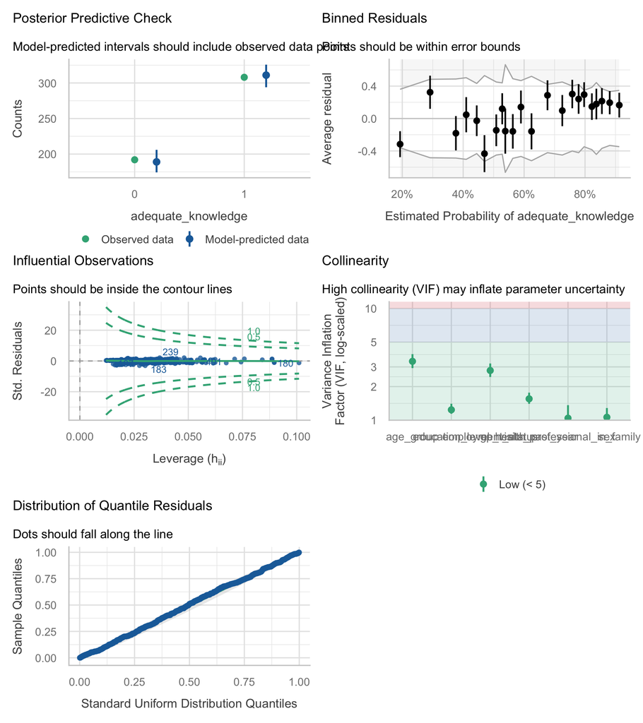

[output not shown]

[output cut: 12 more lines]

| Term | VIF | VIF_CI_low | VIF_CI_high | SE_factor | Tolerance | Tolerance_CI_low | Tolerance_CI_high |
| --- | --- | --- | --- | --- | --- | --- | --- |
| age_group | 3.366696 | 2.928154 | 3.904981 | 1.129069 | 0.2970271 | 0.2560832 | 0.3415121 |
| sex | 1.063008 | 1.013894 | 1.285729 | 1.031023 | 0.9407268 | 0.7777687 | 0.9862962 |
| education_level | 1.239475 | 1.142026 | 1.403786 | 1.055138 | 0.8067931 | 0.7123591 | 0.8756365 |
| employment_status | 2.786189 | 2.438407 | 3.218060 | 1.291971 | 0.3589132 | 0.3107462 | 0.4101039 |
| gp_visits_past_year | 1.554099 | 1.401612 | 1.764484 | 1.076250 | 0.6434596 | 0.5667378 | 0.7134644 |
| health_professional_in_family | 1.043107 | 1.005115 | 1.363321 | 1.021326 | 0.9586740 | 0.7335032 | 0.9949114 |

The diagnostics are satisfactory. The binned-residuals check passes: 100% of binned residuals fall inside their error bounds, against the 95% wanted, so the fitted probabilities track the observed proportions across the range — and that range is reasonably wide, from 0.14 to 0.95, which means the model actually discriminates rather than predicting the base rate for everyone. Collinearity is acceptable: the largest VIF is 3.37 (age_group), elevated by the age-employment overlap described above but below the conventional threshold of 5 — enough to explain why the age and employment coefficients are individually imprecise, not enough to invalidate them. No observation is influential (largest Cook’s distance 0.0196, far below 0.5). There is no separation: every coefficient and standard error is finite, and the sparsest predictor-by-outcome cell still contains 7 respondents (the 18-24 band below the threshold). Homogeneity of variance and normality of residuals are not assumptions of a logistic model, so those panels are not interpreted; the linearity panel is also uninformative because every predictor is categorical.

# Discussion

Among Serbian adults attending primary care, formal education is overwhelmingly the characteristic associated with reaching the adequate-knowledge threshold: tertiary-educated respondents have roughly 3.5 times the odds of secondary-educated ones, and primary-educated respondents about 63% lower odds, holding age, sex, employment and health-service contact constant. Having a family member in health care nearly doubles the odds independently — a plausible informal-information effect. Everything else, including age itself, is explained away by education. Practically, that points campaigns towards low-education audiences specifically, rather than towards the elderly as a group, since the apparent age deficit is really an education deficit.

**Limitations.** The most important limitation is the outcome itself. Adequate knowledge is not a naturally occurring category: it is the 12-item score cut at 9, an author-chosen threshold with no external validation, and dichotomising a continuous score discards information and costs statistical power. The consequence is visible in this file — in the linear analysis of the same underlying score (`knowledge_score.Rmd`) several age contrasts remain significant after adjustment, whereas here every one of them is lost, which is the expected result of throwing away the distinction between a score of 2 and a score of 8. Any conclusion about “adequate knowledge” is also hostage to the cut point: moving it from 9 to 8 or 10 would change both the prevalence and the coefficients. The design is cross-sectional and every predictor is a fixed background characteristic, so nothing here is a causal effect. All predictors are coarse categories, so no per-year or dose-response trend can be tested. The primary-education group (n = 38, of whom 10 reach the threshold) and the 18-24 band (n = 25, of whom 7 fall below it) are both small, so those contrasts are much less precise than they appear. Events per parameter is 13.7, adequate but not generous. Health literacy, income and urban or rural residence are unmeasured and are plausible common causes of both education and knowledge, so residual confounding is likely. The quiz was administered in a clinic to people already consulting a GP, so the sample is not representative of Serbian adults who avoid primary care, and social desirability may inflate scores.

**Future work.** Reporting the continuous score alongside any threshold-based result, and showing how the conclusions change as the threshold moves, would make the dependence on an arbitrary cut point visible rather than hidden.

# Feasibility notes

*Not part of a student report.*